# Final project

Nhóm 12

```r
library(highcharter)
library(corrplot)
library(randomForest)
library(caTools)
library(ROCR)
library(e1071)
library(DAAG)
library(party)
library(rpart)
library(rpart.plot)
library(mlbench)
library(pROC)
library(tree)
library(htmlwidgets)
library('IRdisplay')

library(dplyr)
library(tidyr)
library(ggplot2)
library(tidyverse)
library(ranger)
library(ggpubr)
library(naniar)
library(car)
library(caret)
library(parsnip)
#Import data
dt = read.csv("./data/StudentsPerformance.csv", header = TRUE)
str(dt)
```

```
## 'data.frame':    1000 obs. of  9 variables:
##  $ gender                     : chr  "female" "female" "female" "male" ...
##  $ race.ethnicity             : chr  "group B" "group C" "group B" "group A" ...
##  $ parental_level_of_education: chr  "bachelor's degree" "some college" "master's degree" "associate's degree" ...
##  $ lunch                      : chr  "standard" "standard" "standard" "free/reduced" ...
##  $ test_preparation_course    : chr  "none" "completed" "none" "none" ...
##  $ math_score                 : int  72 69 90 47 76 71 88 40 64 38 ...
##  $ reading_score              : int  72 90 95 57 78 83 95 43 64 60 ...
##  $ writing_score              : int  74 88 93 44 75 78 92 39 67 50 ...
##  $ total_score                : num  72.7 82.3 92.7 49.3 76.3 ...
```

```r
students <- dt %>%
  pivot_longer(cols = c(math_score, reading_score, writing_score), names_to = "subject", values_to = "score") %>%
  separate(subject, c("subject",NA))
students
```

```
## # A tibble: 3,000 × 8
##    gender race.ethnicity parental_level_of…¹ lunch test_…² total…³ subject score
##    <chr>  <chr>          <chr>               <chr> <chr>     <dbl> <chr>   <int>
##  1 female group B        bachelor's degree   stan… none       72.7 math       72
##  2 female group B        bachelor's degree   stan… none       72.7 reading    72
##  3 female group B        bachelor's degree   stan… none       72.7 writing    74
##  4 female group C        some college        stan… comple…    82.3 math       69
##  5 female group C        some college        stan… comple…    82.3 reading    90
##  6 female group C        some college        stan… comple…    82.3 writing    88
##  7 female group B        master's degree     stan… none       92.7 math       90
##  8 female group B        master's degree     stan… none       92.7 reading    95
##  9 female group B        master's degree     stan… none       92.7 writing    93
## 10 male   group A        associate's degree  free… none       49.3 math       47
## # … with 2,990 more rows, and abbreviated variable names
## #   ¹parental_level_of_education, ²test_preparation_course, ³total_score
```

```r
#Tên các biến
names(dt)
```

```
## [1] "gender"                      "race.ethnicity"
## [3] "parental_level_of_education" "lunch"
## [5] "test_preparation_course"     "math_score"
## [7] "reading_score"               "writing_score"
## [9] "total_score"
```

```r
#Kiểu dữ liệu từng biến
sapply(dt, class)
```

```
##                      gender              race.ethnicity
##                 "character"                 "character"
## parental_level_of_education                       lunch
##                 "character"                 "character"
##     test_preparation_course                  math_score
##                 "character"                   "integer"
##               reading_score               writing_score
##                   "integer"                   "integer"
##                 total_score
##                   "numeric"
```

```r
is.null(dt)
```

```
## [1] FALSE
```

```r
sapply(dt %>% select_if(is.numeric), function(x) {sum(is.na(x)) / length(x)})
```

```
##    math_score reading_score writing_score   total_score
##             0             0             0             0
```

```r
sapply(dt %>% select_if(is.character), function(x) {table(x, useNA = "ifany")})
```

```
## $gender
## x
## female   male
##    518    482
##
## $race.ethnicity
## x
## group A group B group C group D group E
##      89     190     319     262     140
##
## $parental_level_of_education
## x
## associate's degree  bachelor's degree        high school    master's degree
##                222                118                196                 59
##       some college   some high school
##                226                179
##
## $lunch
## x
## free/reduced     standard
##          355          645
##
## $test_preparation_course
## x
## completed      none
##       358       642
```

```r
summary(dt)
```

```
##     gender          race.ethnicity     parental_level_of_education
##  Length:1000        Length:1000        Length:1000
##  Class :character   Class :character   Class :character
##  Mode  :character   Mode  :character   Mode  :character
##
##
##
##     lunch           test_preparation_course   math_score     reading_score
##  Length:1000        Length:1000             Min.   :  0.00   Min.   : 17.00
##  Class :character   Class :character        1st Qu.: 57.00   1st Qu.: 59.00
##  Mode  :character   Mode  :character        Median : 66.00   Median : 70.00
##                                             Mean   : 66.09   Mean   : 69.17
##                                             3rd Qu.: 77.00   3rd Qu.: 79.00
##                                             Max.   :100.00   Max.   :100.00
##  writing_score     total_score
##  Min.   : 10.00   Min.   :  9.00
##  1st Qu.: 57.75   1st Qu.: 58.33
##  Median : 69.00   Median : 68.33
##  Mean   : 68.05   Mean   : 67.77
##  3rd Qu.: 79.00   3rd Qu.: 77.67
##  Max.   :100.00   Max.   :100.00
```

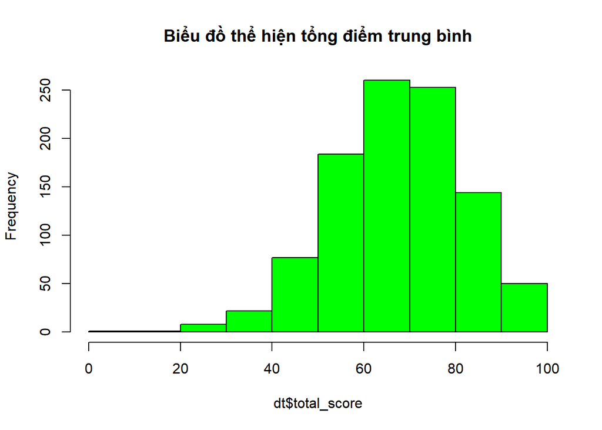

```r
hist(dt$total_score, main = "Biểu đồ thể hiện tổng điểm trung bình", col = "Green")
```

###Câu 1: Thống kê tất cả các biến số có trong tập dữ liệu và đưa ra sự chênh lệch giữa các nhóm với nhau

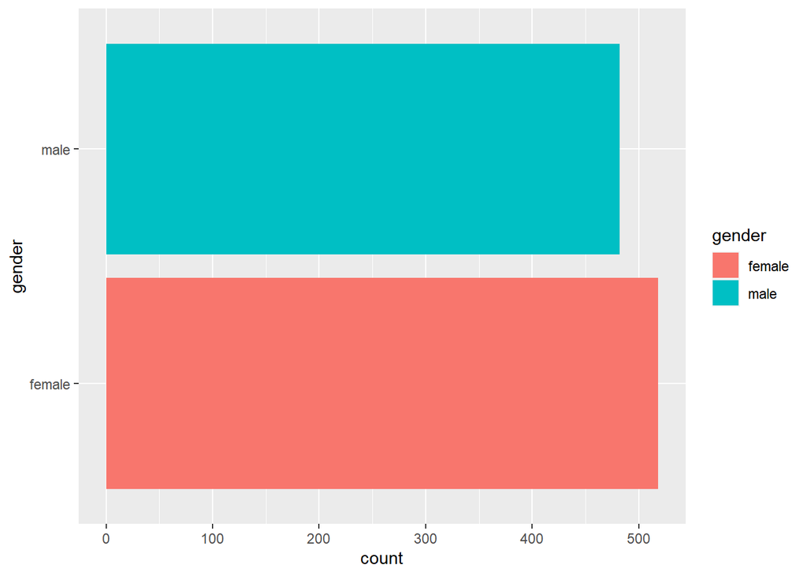

```r
#Gender
ggplot(dt,aes(y = gender,fill=gender)) +
  geom_bar()
```

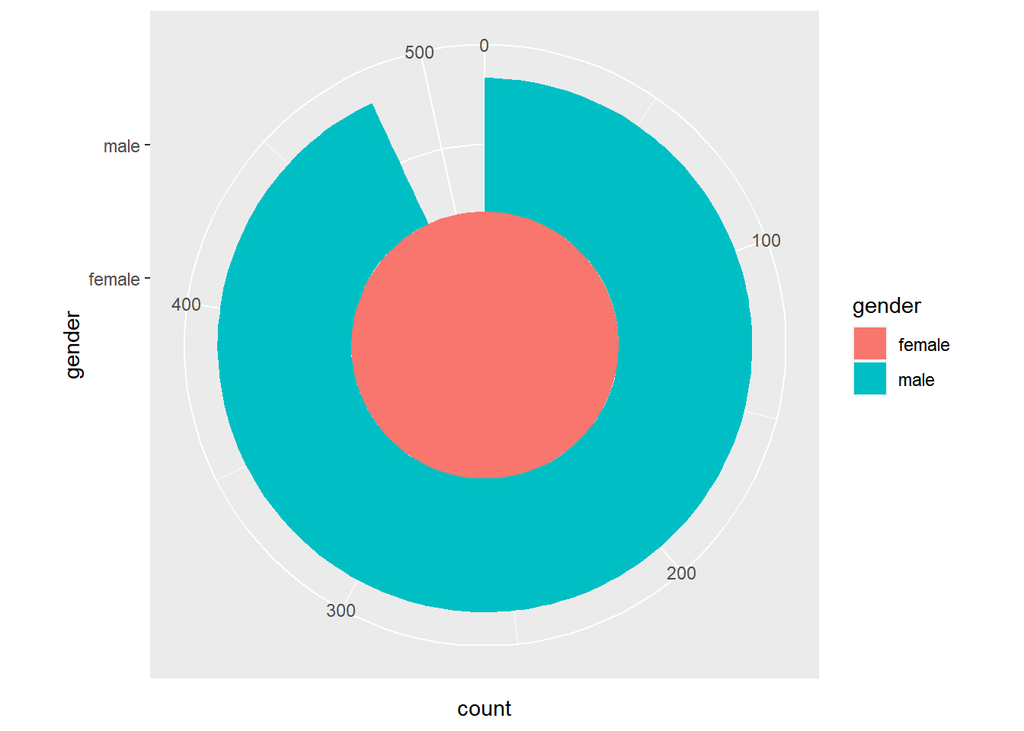

```r
ggplot(dt, aes(y= gender, fill=gender)) +
  geom_bar( width=1) +
  coord_polar(start=0)
```

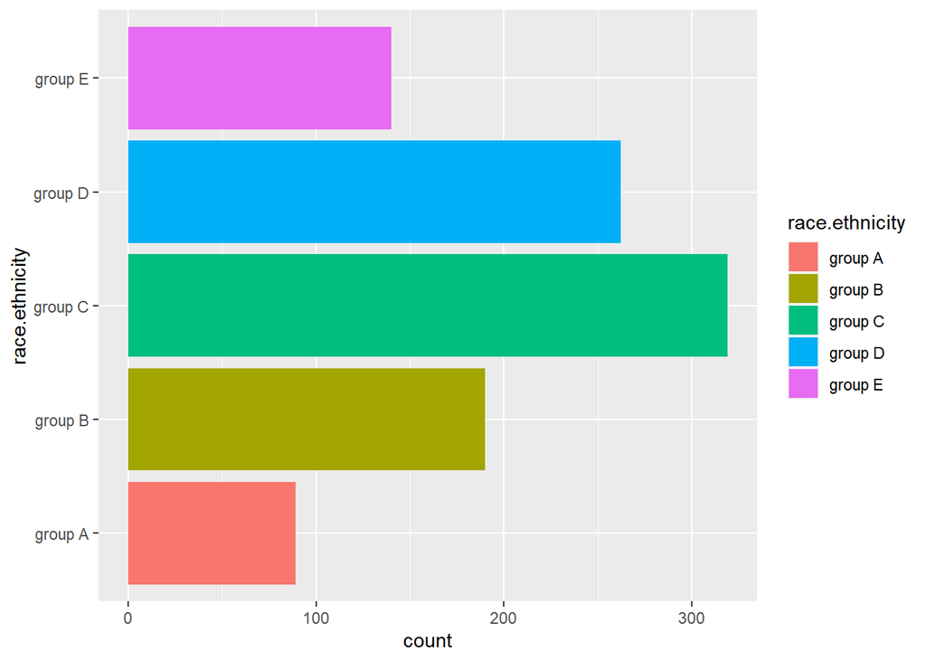

```r
#race.ethnicity
ggplot(dt,aes(y = race.ethnicity ,fill=race.ethnicity )) +
  geom_bar()
```

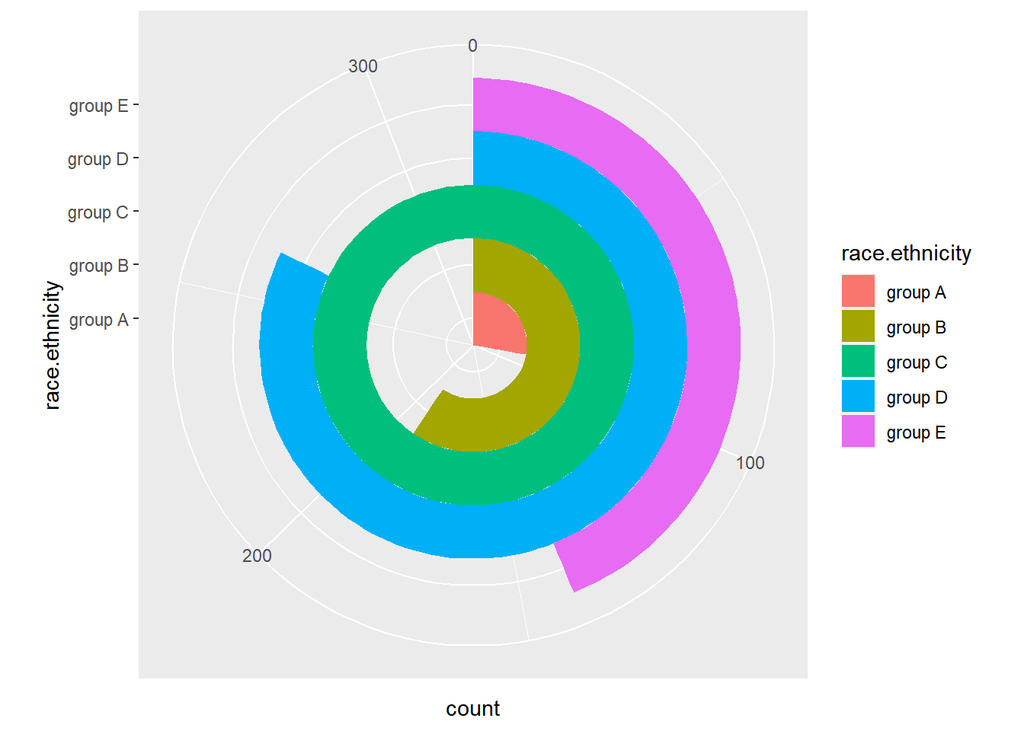

```r
ggplot(dt, aes(y=race.ethnicity , fill=race.ethnicity )) +
  geom_bar( width=1) +
  coord_polar(start=0)
```

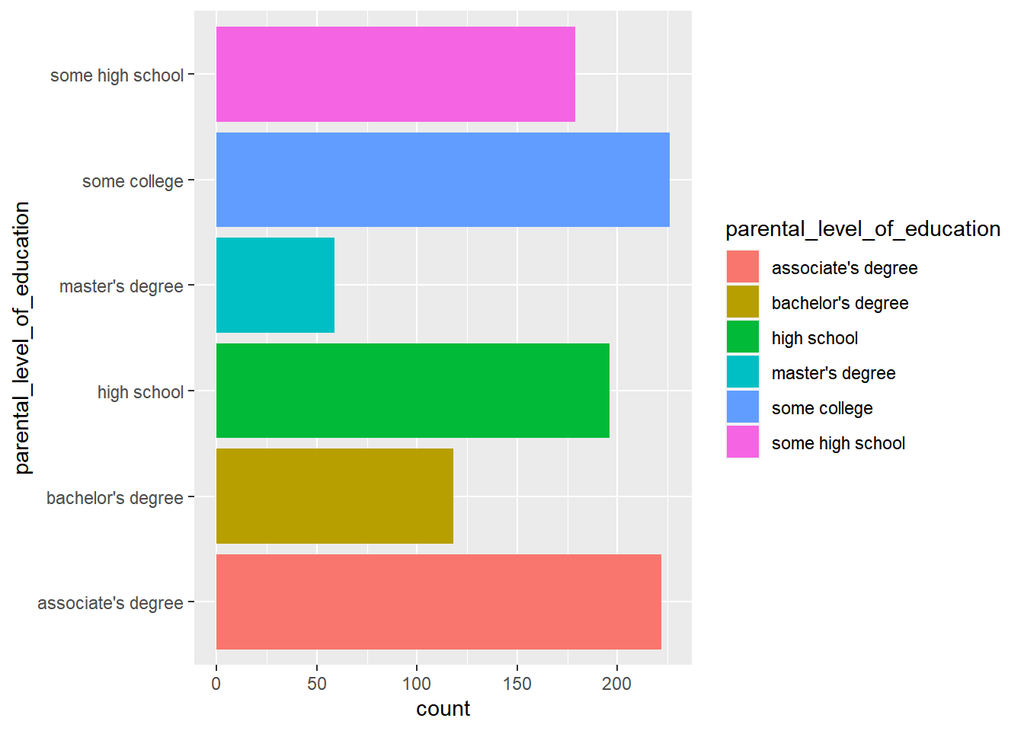

```r
#parental_level_of_education
ggplot(dt,aes(y = parental_level_of_education ,fill=parental_level_of_education )) +
  geom_bar()
```

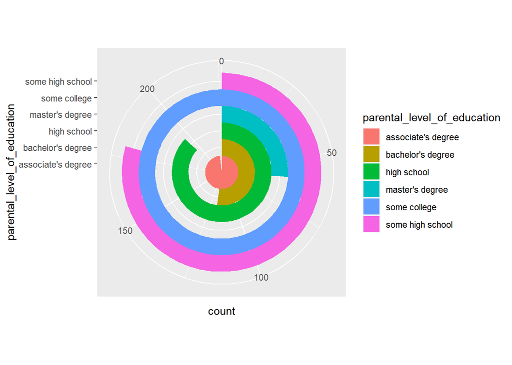

```r
ggplot(dt, aes(y=parental_level_of_education , fill=parental_level_of_education )) +
  geom_bar( width=1) +
  coord_polar(start=0)
```

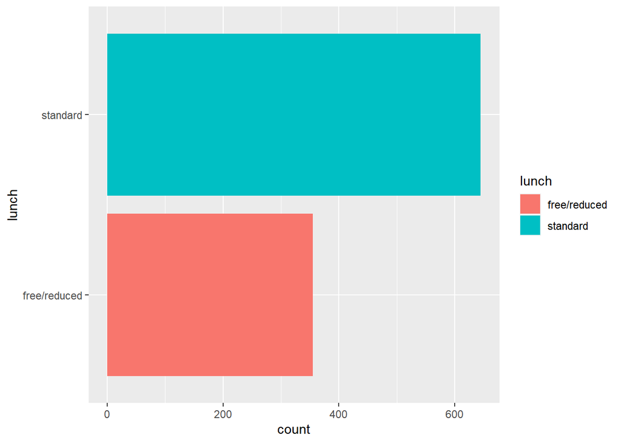

```r
#lunch
ggplot(dt,aes(y = lunch ,fill=lunch )) +
  geom_bar()
```

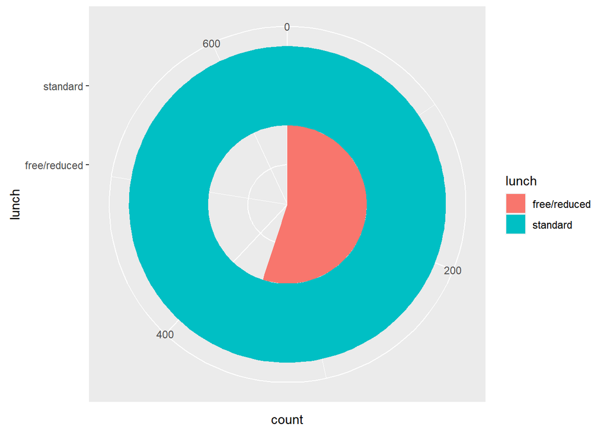

```r
ggplot(dt, aes(y=lunch , fill=lunch )) +
  geom_bar( width=1) +
  coord_polar(start=0)
```

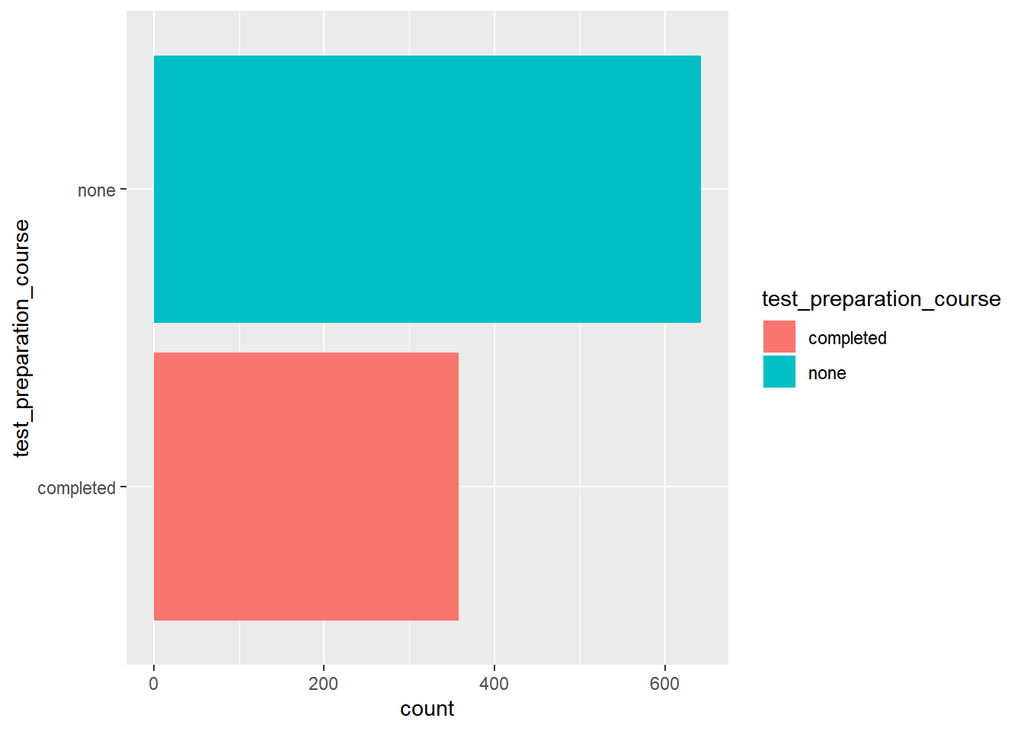

```r
#test_preparation_course
ggplot(dt,aes(y = test_preparation_course ,fill=test_preparation_course  )) +
  geom_bar()
```

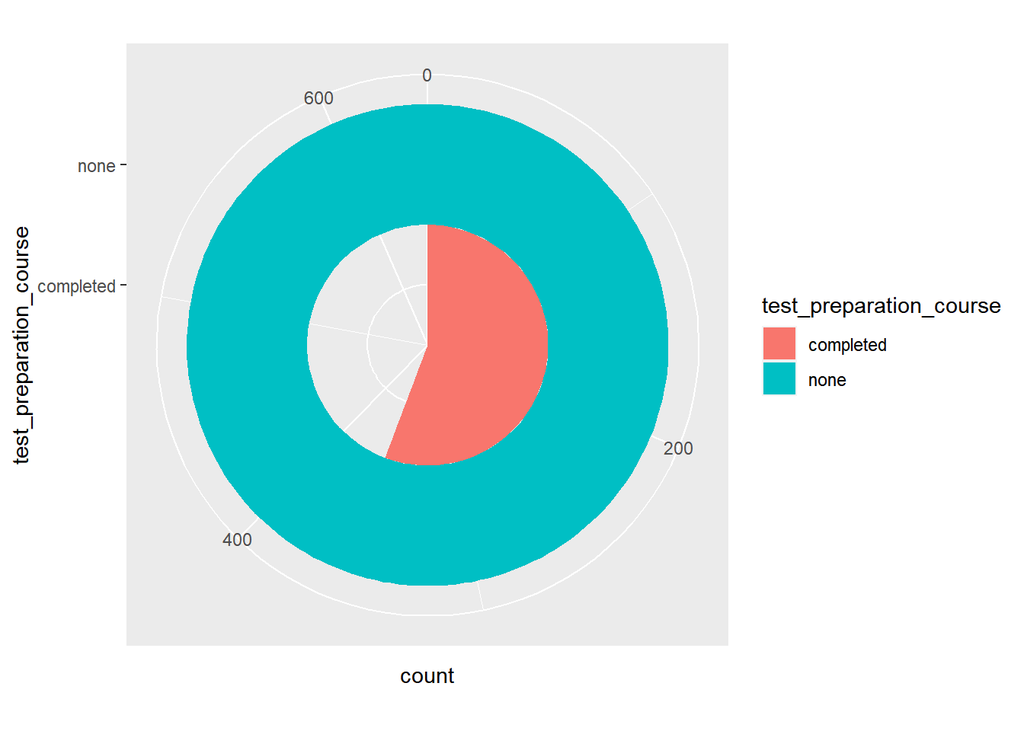

```r
ggplot(dt, aes(y=test_preparation_course  , fill=test_preparation_course  )) +
  geom_bar( width=1) +
  coord_polar(start=0)
```

**Conclusion**: - Qua đồ thị biểu diễn thấy rõ có sự xuất hiện giữa các giá trị trong cùng một biến: + Đối với `giới tính` không có sự khác biệt có ý nghĩa + Đối với `race.ethnicity`, `parental_level_of_education`, `lunch`, `test_preparation_course` có sự khác biệt đáng kể, dễ dàng nhận thấy sự phân chia các nhóm trong cùng một biến không đồng đều như thế nào. -> Như vậy, điều đó có thực sự ảnh hưởng đến kết quả cuối cùng mà học sinh đạt được không?

###Câu 2: Phân tích các yếu tố có ảnh hưởng đến thành tích? Đâu là những yếu tố ảnh hưởng lớn nhất?

```r
#gender
    summary_gender_math <- dt %>% group_by(gender) %>%
      summarise(Total_math = sum(math_score)) %>% mutate(percentage = Total_math/sum(Total_math))

    summary_gender_reading <- dt %>% group_by(gender) %>%
      summarise(Total_reading = sum(reading_score)) %>% mutate(percentage = Total_reading/sum(Total_reading))

    summary_gender_writing <- dt %>% group_by(gender) %>%
      summarise(Total_writing = sum(writing_score)) %>% mutate(percentage = Total_writing/sum(Total_writing))

    math <- summary_gender_math %>%
      hchart("pie", hcaes(x = gender, y = "Total_math"),
             borderWidth = 0, dataLabels = list(enabled = T,
                               distance = -67,
                               style = list(color = "#rf8f9fa",
                                            textOutline = F,
                                            fontWeight = 'bold',
                                            fontSize = 18),
                               format = '<b>{point.name}</b>: {point.percentage:.1f} %', connectorColor = 'silver'))%>%
    hc_colors(c("#fc8eac", "#00ccff"))%>%
    hc_title(text = "Total Maths Score by Gender",
             style = list(color = "#rf8f9fa",
                          textOutline = F,
                          fontWeight = 'bold',
                          fontSize = 18))%>%
    hc_tooltip(pointFormat = '<b>{point.y:.1f}</b>')

    reading <- summary_gender_reading %>%
      hchart("pie", hcaes(x = gender, y = "Total_reading"),
             borderWidth = 0, dataLabels = list(enabled = T,
                               distance = -67,
                               style = list(color = "#rf8f9fa",
                                            textOutline = F,
                                            fontWeight = 'bold',
                                            fontSize = 18),
                               format = '<b>{point.name}</b>: {point.percentage:.1f} %', connectorColor = 'silver'))%>%
    hc_colors(c("#fc8eac", "#00ccff"))%>%
    hc_title(text = "Total Readings Score by Gender",
             style = list(color = "#rf8f9fa",
                          textOutline = F,
                          fontWeight = 'bold',
                          fontSize = 18))%>%
    hc_tooltip(pointFormat = '<b>{point.y:.1f}</b>')

    writing <- summary_gender_writing %>%
      hchart("pie", hcaes(x = gender, y = "Total_writing"),
             borderWidth = 0, dataLabels = list(enabled = T,
                               distance = -67,
                               style = list(color = "#rf8f9fa",
                                            textOutline = F,
                                            fontWeight = 'bold',
                                            fontSize = 18),
                               format = '<b>{point.name}</b>: {point.percentage:.1f} %', connectorColor = 'silver'))%>%
    hc_colors(c("#fc8eac", "#00ccff"))%>%
    hc_title(text = "Total Writings Score by Gender",
             style = list(color = "#rf8f9fa",
                          textOutline = F,
                          fontWeight = 'bold',
                          fontSize = 18))%>%
    hc_tooltip(pointFormat = '<b>{point.y:.1f}</b>')

math
```

[interactive chart not shown]

```r
reading
```

[interactive chart not shown]

```r
writing
```

[interactive chart not shown]

```r
#race.ethnicity
summary_race_math <- dt %>% group_by(race.ethnicity ) %>%
      summarise(Total_math = sum(math_score)) %>% mutate(percentage = Total_math/sum(Total_math))

summary_race_reading <- dt %>% group_by(race.ethnicity ) %>%
      summarise(Total_reading = sum(reading_score)) %>% mutate(percentage = Total_reading/sum(Total_reading))

summary_race_writing <- dt %>% group_by(race.ethnicity ) %>%
      summarise(Total_writing = sum(writing_score)) %>% mutate(percentage = Total_writing/sum(Total_writing))

    math <- summary_race_math %>%
      hchart("pie", hcaes(x = race.ethnicity, y = "Total_math"),
             borderWidth = 0, dataLabels = list(enabled = T,
                               distance = -67,
                               style = list(color = "#rf8f9fa",
                                            textOutline = F,
                                            fontWeight = 'bold',
                                            fontSize = 13),
                               format = '<b>{point.name}</b>: {point.percentage:.1f} %', connectorColor = 'silver'))%>%
    hc_colors(c("#fc8eac", "#00ccff","#00ff99","#ffff66","#ff9900"))%>%
    hc_title(text = "Total Maths Score by Race/Ethnicity",
             style = list(color = "#rf8f9fa",
                          textOutline = F,
                          fontWeight = 'bold',
                          fontSize = 18))%>%
    hc_tooltip(pointFormat = '<b>{point.y:.1f}</b>')

        reading <- summary_race_reading %>%
      hchart("pie", hcaes(x = race.ethnicity, y = "Total_reading"),
             borderWidth = 0, dataLabels = list(enabled = T,
                               distance = -67,
                               style = list(color = "#rf8f9fa",
                                            textOutline = F,
                                            fontWeight = 'bold',
                                            fontSize = 13),
                               format = '<b>{point.name}</b>: {point.percentage:.1f} %', connectorColor = 'silver'))%>%
    hc_colors(c("#fc8eac", "#00ccff","#00ff99","#ffff66","#ff9900"))%>%
    hc_title(text = "Total Reading Score by Race/Ethnicity",
             style = list(color = "#rf8f9fa",
                          textOutline = F,
                          fontWeight = 'bold',
                          fontSize = 18))%>%
    hc_tooltip(pointFormat = '<b>{point.y:.1f}</b>')


     writing <- summary_race_writing %>%
      hchart("pie", hcaes(x = race.ethnicity, y = "Total_writing"),
             borderWidth = 0, dataLabels = list(enabled = T,
                               distance = -67,
                               style = list(color = "#rf8f9fa",
                                            textOutline = F,
                                            fontWeight = 'bold',
                                            fontSize = 13),
                               format = '<b>{point.name}</b>: {point.percentage:.1f} %', connectorColor = 'silver'))%>%
    hc_colors(c("#fc8eac", "#00ccff","#00ff99","#ffff66","#ff9900"))%>%
    hc_title(text = "Total Writing Score by Race/Ethnicity",
             style = list(color = "#rf8f9fa",
                          textOutline = F,
                          fontWeight = 'bold',
                          fontSize = 18))%>%
    hc_tooltip(pointFormat = '<b>{point.y:.1f}</b>')


math
```

[interactive chart not shown]

```r
reading
```

[interactive chart not shown]

```r
writing
```

[interactive chart not shown]

```r
#parental_level_of_education

summary_parental_math <- dt %>% group_by(parental_level_of_education ) %>%
      summarise(Total_math = sum(math_score)) %>% mutate(percentage = Total_math/sum(Total_math))

summary_parental_reading <- dt %>% group_by(parental_level_of_education ) %>%
      summarise(Total_reading = sum(reading_score)) %>% mutate(percentage = Total_reading/sum(Total_reading))

summary_parental_writing <- dt %>% group_by(parental_level_of_education) %>%
      summarise(Total_writing = sum(writing_score)) %>% mutate(percentage = Total_writing/sum(Total_writing))

    math <- summary_parental_math %>%
      hchart("pie", hcaes(x = parental_level_of_education, y = "Total_math"),
             borderWidth = 0, dataLabels = list(enabled = T,
                               distance = -67,
                               style = list(color = "#rf8f9fa",
                                            textOutline = F,
                                            fontWeight = 'bold',
                                            fontSize = 11),
                               format = '<b>{point.name}</b>: {point.percentage:.1f} %', connectorColor = 'silver'))%>%
    hc_colors(c("#fc8eac", "#00ccff","#00ff99","#ffff66","#ff9900","#9999ff"))%>%
    hc_title(text = "Total Maths Score by Parental level of education",
             style = list(color = "#rf8f9fa",
                          textOutline = F,
                          fontWeight = 'bold',
                          fontSize = 18))%>%
    hc_tooltip(pointFormat = '<b>{point.y:.1f}</b>')

        reading <- summary_parental_reading %>%
      hchart("pie", hcaes(x = parental_level_of_education, y = "Total_reading"),
             borderWidth = 0, dataLabels = list(enabled = T,
                               distance = -67,
                               style = list(color = "#rf8f9fa",
                                            textOutline = F,
                                            fontWeight = 'bold',
                                            fontSize = 11),
                               format = '<b>{point.name}</b>: {point.percentage:.1f} %', connectorColor = 'silver'))%>%
    hc_colors(c("#fc8eac", "#00ccff","#00ff99","#ffff66","#ff9900","#9999ff"))%>%
    hc_title(text = "Total Reading Score by Parental level of education",
             style = list(color = "#rf8f9fa",
                          textOutline = F,
                          fontWeight = 'bold',
                          fontSize = 18))%>%
    hc_tooltip(pointFormat = '<b>{point.y:.1f}</b>')


     writing <- summary_parental_writing %>%
      hchart("pie", hcaes(x = parental_level_of_education, y = "Total_writing"),
             borderWidth = 0, dataLabels = list(enabled = T,
                               distance = -67,
                               style = list(color = "#rf8f9fa",
                                            textOutline = F,
                                            fontWeight = 'bold',
                                            fontSize = 11),
                               format = '<b>{point.name}</b>: {point.percentage:.1f} %', connectorColor = 'silver'))%>%
    hc_colors(c("#fc8eac", "#00ccff","#00ff99","#ffff66","#ff9900","#9999ff"))%>%
    hc_title(text = "Total Writing Score by Parental level of education",
             style = list(color = "#rf8f9fa",
                          textOutline = F,
                          fontWeight = 'bold',
                          fontSize = 18))%>%
    hc_tooltip(pointFormat = '<b>{point.y:.1f}</b>')


math
```

[interactive chart not shown]

```r
reading
```

[interactive chart not shown]

```r
writing
```

[interactive chart not shown]

```r
#lunch
    summary_lunch_math <- dt %>% group_by(lunch) %>%
      summarise(Total_math = sum(math_score)) %>% mutate(percentage = Total_math/sum(Total_math))

    summary_lunch_reading <- dt %>% group_by(lunch) %>%
      summarise(Total_reading = sum(reading_score)) %>% mutate(percentage = Total_reading/sum(Total_reading))

    summary_lunch_writing <- dt %>% group_by(lunch) %>%
      summarise(Total_writing = sum(writing_score)) %>% mutate(percentage = Total_writing/sum(Total_writing))

    math <- summary_lunch_math %>%
      hchart("pie", hcaes(x = lunch, y = "Total_math"),
             borderWidth = 0, dataLabels = list(enabled = T,
                               distance = -67,
                               style = list(color = "#rf8f9fa",
                                            textOutline = F,
                                            fontWeight = 'bold',
                                            fontSize = 18),
                               format = '<b>{point.name}</b>: {point.percentage:.1f} %', connectorColor = 'silver'))%>%
    hc_colors(c("#fc8eac", "#00ccff"))%>%
    hc_title(text = "Total Maths Score by Lunch",
             style = list(color = "#rf8f9fa",
                          textOutline = F,
                          fontWeight = 'bold',
                          fontSize = 18))%>%
    hc_tooltip(pointFormat = '<b>{point.y:.1f}</b>')

    reading <- summary_lunch_reading %>%
      hchart("pie", hcaes(x = lunch, y = "Total_reading"),
             borderWidth = 0, dataLabels = list(enabled = T,
                               distance = -67,
                               style = list(color = "#rf8f9fa",
                                            textOutline = F,
                                            fontWeight = 'bold',
                                            fontSize = 18),
                               format = '<b>{point.name}</b>: {point.percentage:.1f} %', connectorColor = 'silver'))%>%
    hc_colors(c("#fc8eac", "#00ccff"))%>%
    hc_title(text = "Total Readings Score by Lunch",
             style = list(color = "#rf8f9fa",
                          textOutline = F,
                          fontWeight = 'bold',
                          fontSize = 18))%>%
    hc_tooltip(pointFormat = '<b>{point.y:.1f}</b>')

    writing <- summary_lunch_writing %>%
      hchart("pie", hcaes(x = lunch, y = "Total_writing"),
             borderWidth = 0, dataLabels = list(enabled = T,
                               distance = -67,
                               style = list(color = "#rf8f9fa",
                                            textOutline = F,
                                            fontWeight = 'bold',
                                            fontSize = 18),
                               format = '<b>{point.name}</b>: {point.percentage:.1f} %', connectorColor = 'silver'))%>%
    hc_colors(c("#fc8eac", "#00ccff"))%>%
    hc_title(text = "Total Writings Score by Lunch",
             style = list(color = "#rf8f9fa",
                          textOutline = F,
                          fontWeight = 'bold',
                          fontSize = 18))%>%
    hc_tooltip(pointFormat = '<b>{point.y:.1f}</b>')

math
```

[interactive chart not shown]

```r
reading
```

[interactive chart not shown]

```r
writing
```

[interactive chart not shown]

```r
#test_preparation_course
    summary_preparation_math <- dt %>% group_by(test_preparation_course) %>%
      summarise(Total_math = sum(math_score)) %>% mutate(percentage = Total_math/sum(Total_math))

    summary_preparation_reading <- dt %>% group_by(test_preparation_course) %>%
      summarise(Total_reading = sum(reading_score)) %>% mutate(percentage = Total_reading/sum(Total_reading))

    summary_preparation_writing <- dt %>% group_by(test_preparation_course) %>%
      summarise(Total_writing = sum(writing_score)) %>% mutate(percentage = Total_writing/sum(Total_writing))

    math <- summary_preparation_math %>%
      hchart("pie", hcaes(x = test_preparation_course, y = "Total_math"),
             borderWidth = 0, dataLabels = list(enabled = T,
                               distance = -67,
                               style = list(color = "#rf8f9fa",
                                            textOutline = F,
                                            fontWeight = 'bold',
                                            fontSize = 18),
                               format = '<b>{point.name}</b>: {point.percentage:.1f} %', connectorColor = 'silver'))%>%
    hc_colors(c("#fc8eac", "#00ccff"))%>%
    hc_title(text = "Total Maths Score by Test preparation course",
             style = list(color = "#rf8f9fa",
                          textOutline = F,
                          fontWeight = 'bold',
                          fontSize = 18))%>%
    hc_tooltip(pointFormat = '<b>{point.y:.1f}</b>')

    reading <- summary_preparation_reading %>%
      hchart("pie", hcaes(x = test_preparation_course, y = "Total_reading"),
             borderWidth = 0, dataLabels = list(enabled = T,
                               distance = -67,
                               style = list(color = "#rf8f9fa",
                                            textOutline = F,
                                            fontWeight = 'bold',
                                            fontSize = 18),
                               format = '<b>{point.name}</b>: {point.percentage:.1f} %', connectorColor = 'silver'))%>%
    hc_colors(c("#fc8eac", "#00ccff"))%>%
    hc_title(text = "Total Readings Score by Test preparation course",
             style = list(color = "#rf8f9fa",
                          textOutline = F,
                          fontWeight = 'bold',
                          fontSize = 18))%>%
    hc_tooltip(pointFormat = '<b>{point.y:.1f}</b>')

    writing <- summary_preparation_writing %>%
      hchart("pie", hcaes(x = test_preparation_course, y = "Total_writing"),
             borderWidth = 0, dataLabels = list(enabled = T,
                               distance = -67,
                               style = list(color = "#rf8f9fa",
                                            textOutline = F,
                                            fontWeight = 'bold',
                                            fontSize = 18),
                               format = '<b>{point.name}</b>: {point.percentage:.1f} %', connectorColor = 'silver'))%>%
    hc_colors(c("#fc8eac", "#00ccff"))%>%
    hc_title(text = "Total Writings Score by Test preparation course",
             style = list(color = "#rf8f9fa",
                          textOutline = F,
                          fontWeight = 'bold',
                          fontSize = 18))%>%
    hc_tooltip(pointFormat = '<b>{point.y:.1f}</b>')

math
```

[interactive chart not shown]

```r
reading
```

[interactive chart not shown]

```r
writing
```

[interactive chart not shown]

**Conclusion**: - Sau khi chỉ ra mối tương quan giữa các biến môi trường và biến kết quả, chúng ta có thể thấy sự khác biệt về kết quả đạt được ở các nhóm khác nhau trong cùng một biến. - Tuy nhiên, nếu nhìn sâu hơn vào số lượng nhóm và kết quả đạt được, chúng ta có thể thấy rằng số lượng người tham gia khảo sát giữa các nhóm sẽ ảnh hưởng trực tiếp đến tổng số điểm đạt được. Do đó, mặc dù chúng ta có thể dễ dàng nhận ra mức độ khác biệt giữa các nhóm nhưng vẫn không thể đưa ra kết luận biến nào sẽ có tác động lớn nhất đến kết quả đạt được vì thực nghiệm chỉ mang tính khái quát.

###Câu 3:Mối quan hệ giữa các biến khác với test_preparation_course trong tập dữ liệu? Lí do nào học sinh không thể tham gia các khóa luyện ?

```r
#gender

 summary_test_preparation <- dt %>% group_by(gender)%>% count(test_preparation_course)

    ### Setting the colours
    summary_test_preparation$coll <- ifelse(summary_test_preparation$test_preparation_course == "completed", '#40e0d0', '#4d9385')

      ### Column chart with highcharter package
      gender_plot <- summary_test_preparation %>%
      hchart("column", hcaes(y = "n", group = "test_preparation_course"),
             stacking = "normal",
             borderLine = F,
             dataLabels = list(enabled = T,
                               distance = -67,
                               style = list(color = "#112d31",
                                            textOutline = F,
                                            fontSize = 15)))%>%
      hc_chart(inverted = T,
               polar = T)%>%

      hc_plotOptions(series = list(
        borderRadius = 5,
        pointPadding = 0,
        groupPadding = 0.15,
        borderWidth = 0))%>%

      hc_pane(innerSize = '20%',
              endAngle = 270)%>%

      hc_xAxis(categories = c("Male", "Female"),
               gridLineWidth = F,
               labels = list(align = "right",
                             y = 3,
                             style = list(color = "#rf8f9fa",
                                          textOutline = F,
                                          fontWeight = 'bold',
                                          fontSize = 20)),
               stackLabels = list(enabled = T,
                                  style = list(color = "#rf8f9fa",
                                               textOutline = F,
                                               fontWeight = 'bold',
                                               fontSize = 15))) %>%
      hc_yAxis(visible = F,
               stackLabels = list(enabled = T,
                                  style = list(color = "#rf8f9fa",
                                               textOutline = F,
                                               fontWeight = 'bold',
                                               fontSize = 15)))%>%
      hc_title(text = "Gender Prepared for the Exams",
               style = list(color = "#rf8f9fa",
                            textOutline = F,
                            fontWeight = 'bold',
                            fontSize = 18),
               y = 50)%>%
      hc_legend(labelFormat = '<span style="color:{color}">{name}</span')%>%
      hc_colors(summary_test_preparation$coll)
    gender_plot
```

[interactive chart not shown]

```r
#race.ethnicity
summary_test_preparation <- dt %>% group_by(race.ethnicity)%>% count(test_preparation_course)

    ### Setting the colours
    summary_test_preparation$coll <- ifelse(summary_test_preparation$test_preparation_course == "completed", '#40e0d0', '#4d9385')

      ### Column chart with highcharter package
      race_plot <- summary_test_preparation %>%
      hchart("column", hcaes(y = "n", group = "test_preparation_course"),
             stacking = "normal",
             borderLine = F,
             dataLabels = list(enabled = T,
                               distance = -67,
                               style = list(color = "#112d31",
                                            textOutline = F,
                                            fontSize = 15)))%>%
      hc_chart(inverted = T,
               polar = T)%>%

      hc_plotOptions(series = list(
        borderRadius = 5,
        pointPadding = 0,
        groupPadding = 0.15,
        borderWidth = 0))%>%

      hc_pane(innerSize = '20%',
              endAngle = 270)%>%

      hc_xAxis(categories = c("Group A", "Group B", "Group C", "Group D", "Group E"),
               gridLineWidth = F,
               labels = list(align = "right",
                             y = 3,
                             style = list(color = "#rf8f9fa",
                                          textOutline = F,
                                          fontWeight = 'bold',
                                          fontSize = 12)),
               stackLabels = list(enabled = T,
                                  style = list(color = "#rf8f9fa",
                                               textOutline = F,
                                               fontWeight = 'bold',
                                               fontSize = 15))) %>%
      hc_yAxis(visible = F,
               stackLabels = list(enabled = T,
                                  style = list(color = "#rf8f9fa",
                                               textOutline = F,
                                               fontWeight = 'bold',
                                               fontSize = 15)))%>%
      hc_title(text = "Race/Ethnicity Prepared for the Exams",
               style = list(color = "#rf8f9fa",
                            textOutline = F,
                            fontWeight = 'bold',
                            fontSize = 18),
               y = 50)%>%
      hc_legend(labelFormat = '<span style="color:{color}">{name}</span')%>%
      hc_colors(summary_test_preparation$coll)
    race_plot
```

[interactive chart not shown]

```r
#parental_level_of_education
summary_test_preparation <- dt %>% group_by(parental_level_of_education)%>% count(test_preparation_course)

    ### Setting the colours
    summary_test_preparation$coll <- ifelse(summary_test_preparation$test_preparation_course == "completed", '#40e0d0', '#4d9385')

      ### Column chart with highcharter package
      parental_plot <- summary_test_preparation %>%
      hchart("column", hcaes(y = "n", group = "test_preparation_course"),
             stacking = "normal",
             borderLine = F,
             dataLabels = list(enabled = T,
                               distance = -67,
                               style = list(color = "#112d31",
                                            textOutline = F,
                                            fontSize = 15)))%>%
      hc_chart(inverted = T,
               polar = T)%>%

      hc_plotOptions(series = list(
        borderRadius = 5,
        pointPadding = 0,
        groupPadding = 0.15,
        borderWidth = 0))%>%

      hc_pane(innerSize = '20%',
              endAngle = 270)%>%

      hc_xAxis(categories = c("associate's degree", "bachelor's degree", "high school","master's degree", "some college", "some high school"),
               gridLineWidth = F,
               labels = list(align = "right",
                             y = 3,
                             style = list(color = "#rf8f9fa",
                                          textOutline = F,
                                          fontWeight = 'bold',
                                          fontSize = 10)),
               stackLabels = list(enabled = T,
                                  style = list(color = "#rf8f9fa",
                                               textOutline = F,
                                               fontWeight = 'bold',
                                               fontSize = 15))) %>%
      hc_yAxis(visible = F,
               stackLabels = list(enabled = T,
                                  style = list(color = "#rf8f9fa",
                                               textOutline = F,
                                               fontWeight = 'bold',
                                               fontSize = 15)))%>%
      hc_title(text = "Parentals Prepared for the Exams",
               style = list(color = "#rf8f9fa",
                            textOutline = F,
                            fontWeight = 'bold',
                            fontSize = 18),
               y = 50)%>%
      hc_legend(labelFormat = '<span style="color:{color}">{name}</span')%>%
      hc_colors(summary_test_preparation$coll)
    parental_plot
```

[interactive chart not shown]

```r
#lunch

 summary_test_preparation <- dt %>% group_by(lunch)%>% count(test_preparation_course)

    ### Setting the colours
    summary_test_preparation$coll <- ifelse(summary_test_preparation$test_preparation_course == "completed", '#40e0d0', '#4d9385')

      ### Column chart with highcharter package
      lunch_plot <- summary_test_preparation %>%
      hchart("column", hcaes(y = "n", group = "test_preparation_course"),
             stacking = "normal",
             borderLine = F,
             dataLabels = list(enabled = T,
                               distance = -67,
                               style = list(color = "#112d31",
                                            textOutline = F,
                                            fontSize = 15)))%>%
      hc_chart(inverted = T,
               polar = T)%>%

      hc_plotOptions(series = list(
        borderRadius = 5,
        pointPadding = 0,
        groupPadding = 0.15,
        borderWidth = 0))%>%

      hc_pane(innerSize = '20%',
              endAngle = 270)%>%

      hc_xAxis(categories = c("free/reduced", "standard" ),
               gridLineWidth = F,
               labels = list(align = "right",
                             y = 3,
                             style = list(color = "#rf8f9fa",
                                          textOutline = F,
                                          fontWeight = 'bold',
                                          fontSize = 18)),
               stackLabels = list(enabled = T,
                                  style = list(color = "#rf8f9fa",
                                               textOutline = F,
                                               fontWeight = 'bold',
                                               fontSize = 15))) %>%
      hc_yAxis(visible = F,
               stackLabels = list(enabled = T,
                                  style = list(color = "#rf8f9fa",
                                               textOutline = F,
                                               fontWeight = 'bold',
                                               fontSize = 15)))%>%
      hc_title(text = "Lunch Prepared for the Exams",
               style = list(color = "#rf8f9fa",
                            textOutline = F,
                            fontWeight = 'bold',
                            fontSize = 18),
               y = 50)%>%
      hc_legend(labelFormat = '<span style="color:{color}">{name}</span')%>%
      hc_colors(summary_test_preparation$coll)
    lunch_plot
```

[interactive chart not shown]

**Conculsion**: - Sau khi thống kê, chúng ta dễ dàng nhận thấy biến `giới tính` không tác động nhiều đến số lượng quan sát do sự khác biệt giữa `nam` và `nữ` là không nhiều. - Tuy nhiên, đối với các biến khác như: `race.ethnicity`, `lunch`, `parental_level_of_education` thì có sự phân biệt rõ ràng giữa các trường dữ liệu, mức độ chênh lệch lớn. Như vậy, chúng ta có thể kết luận rằng các biến: `race.ethnicity`, `lunch`, `parental_level_of_education` là nguyên nhân dẫn đến sự không đồng nhất của biến `test_preparation_course`.

###Modeling ##Câu hỏi 1: Mục đích của công việc phân tích này là tìm hiểu xem liệu có mối quan hệ đáng kể nào giữa giới tính, thu nhập của cha mẹ, trình độ học vấn của cha mẹ và điểm kiểm tra hay không.

nhóm chúng em đã phân tích dữ liệu bằng cách chọn ba chủ đề sau:

Mối quan hệ giữa giới tính và điểm kiểm tra Mối quan hệ giữa thu nhập của cha mẹ và điểm kiểm tra Mối quan hệ giữa trình độ học vấn của cha mẹ và điểm kiểm tra

Bộ dữ liệu StudentPerformance có ba biến số điểm: toán, đọc và viết. Tìm hiểu xem các biến giới tính, bữa ăn trưa và trình độ học vấn của cha mẹ khác nhau như thế nào ở các lớp và kiểm tra xem sự khác biệt có đáng kể hay không thông qua một bài kiểm tra

1. Mối quan hệ giữa giới tính và điểm thi Đầu tiên ta tiến hành điều tra và phân tích mối quan hệ giữa giới tính có liên quan đến điểm thi của học sinh hay không

Sau khi chỉ nhập các biến chúng em muốn từ tập dữ liệu, sau đó tìm giá trị trung bình của từng đối tượng cho nam và nữ và so sánh sự khác biệt

```r
Students <- subset(dt, select = c(-race.ethnicity,-test_preparation_course, -lunch,-parental_level_of_education))
# loại các biến -race.ethnicity,-test_preparation_course, -lunch,-parental_level_of_education
colnames(Students) <-  c("Gender","Math_Score","Reading_Score","Writing_Score","Total_Score")
# đổi tên các biến Gender","Math_Score","Reading_Score","Writing_Score
head(Students)
```

```
##   Gender Math_Score Reading_Score Writing_Score Total_Score
## 1 female         72            72            74    72.66667
## 2 female         69            90            88    82.33333
## 3 female         90            95            93    92.66667
## 4   male         47            57            44    49.33333
## 5   male         76            78            75    76.33333
## 6 female         71            83            78    77.33333
```

```r
students <- Students %>%
  pivot_longer(cols = c(Math_Score, Reading_Score, Writing_Score), names_to = "subject", values_to = "score") %>%
  separate(subject, c("subject",NA))
head(students)
```

```
## # A tibble: 6 × 4
##   Gender Total_Score subject score
##   <chr>        <dbl> <chr>   <int>
## 1 female        72.7 Math       72
## 2 female        72.7 Reading    72
## 3 female        72.7 Writing    74
## 4 female        82.3 Math       69
## 5 female        82.3 Reading    90
## 6 female        82.3 Writing    88
```

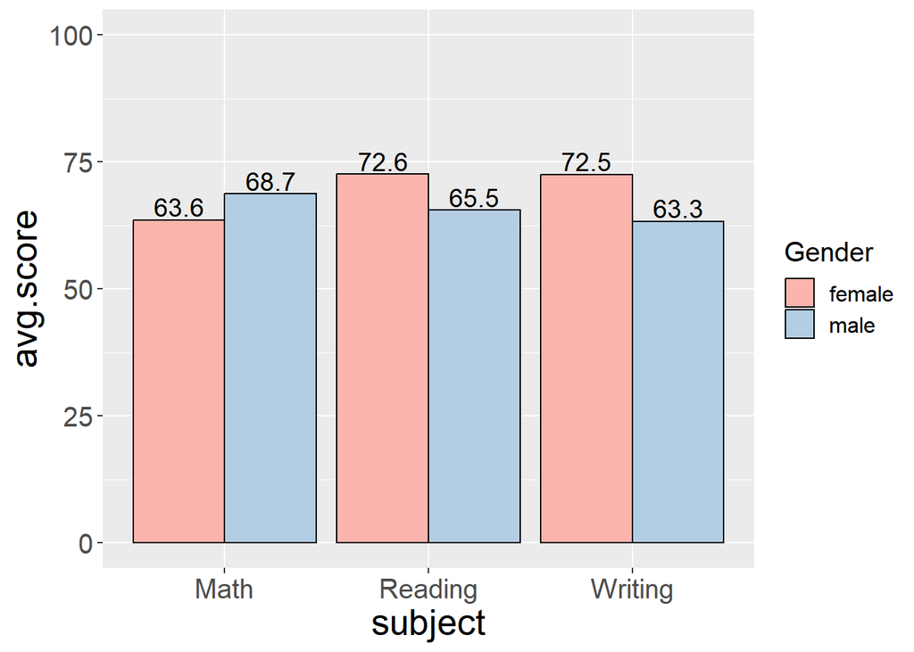

```r
gender_score <- students %>%
  group_by(Gender, subject) %>%
  summarise(
    avg.score = round(mean(score),1),
    std.score = round(sd(score),1),
    .groups = "drop"
  )
#tạo tập dữ liệu trung bình điểm các môn toán, đọc, viết theo giới tính

bp<-ggplot(gender_score,
       aes(
         x = subject,
         y = avg.score,
         fill = Gender
       )) +
  geom_bar(stat = "identity",
           position = "dodge",
           color = "black"
  ) +
  scale_fill_brewer(palette = "Pastel1") +
  geom_text(aes(label = avg.score),
            position = position_dodge(0.9),
            vjust = -0.2,
            size = 5) +
  ylim(0,100) +
  theme(
    axis.text = element_text(size = 15),
    axis.title = element_text(size = 20),
    legend.text = element_text(size = 12),
    legend.title = element_text(size = 15)
  )
plot(bp) # thể hiện tập dữ liệu trung bình điểm các môn toán, đọc, viết theo giới tính dưới dạng biểu đồ
```

Học sinh nam có điểm trung bình môn Toán cao hơn và học sinh nữ có điểm trung bình môn Đọc và Viết cao hơn.

Để tìm hiểu sự phân bố điểm của học sinh, nhóm chúng em chia khoảng điểm thành các khoảng 10 điểm và vẽ biểu đồ phân phối của học sinh dưới dạng biểu đồ histogram.

```r
histogram <- students %>%
  mutate( bin = cut_interval(score, n=10) )%>%
  group_by(bin, Gender, subject) %>%
  summarise(
    n = n(),
    .groups = "drop"
  )
```

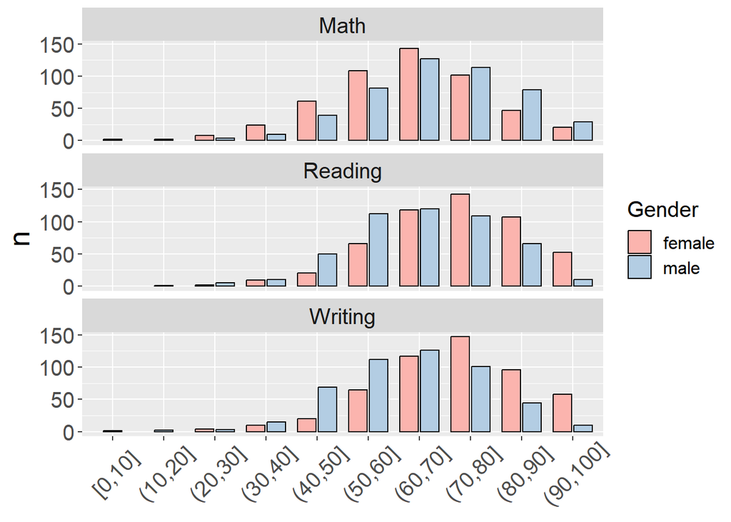

```r
hist <- ggplot(histogram,
       aes(
         x = bin,
         y = n,
         fill = Gender
       )) +
  geom_bar(stat = "identity",
           position = position_dodge2(preserve = "single"),
           color = "black",
           width = 0.8) +
  facet_wrap(~subject, nrow = 3) +
  scale_fill_brewer(palette = "Pastel1") +
  theme(
    axis.text.x = element_text(angle = 45, vjust = 0.6),
    axis.title.x = element_blank(),
    axis.text = element_text(size = 15),
    axis.title = element_text(size = 20),
    legend.text = element_text(size = 12),
    legend.title = element_text(size = 15),
    strip.text = element_text(size = 15)
  )

hist
```

quán sát ở phổ điểm môn toán, từ những thang điểm cao từ 70 đến 100 điểm, tỉ lệ học sinh nam đạt điểm cao này nhiều hơn ở học sinh nữ và ngược lại ở hai môn đọc và viết thì từ thang điểm 70 đến 100 thì học sinh nữ dẫn đầu suy ra: Tỉ lệ học sinh nam đứng đầu môn Toán cao, tỉ lệ học sinh nữ đứng đầu môn Đọc và Viết cao.

Nó có thể là kết quả của sự khác biệt về số lượng học sinh,

Vì vậy nhóm chúng em đã so sánh số lượng học sinh nam và nữ.

```r
table(Students$Gender)
```

```
##
## female   male
##    518    482
```

Học sinh nữ chiếm 51,8% và học sinh nam chiếm 48,2%, không có sự khác biệt có ý nghĩa thống kê giữa học sinh nam và nữ.

Một bài kiểm tra nên được tiến hành để xác định xem sự khác biệt về điểm trung bình giữa học sinh nam và nữ được xác định trước đó có đáng kể hay không.

Đặt giả thuyết H0: không có sự khác biệt về kết quả học tập của sinh viên theo giới tính (phương sai của hai tổng thể là bằng nhau)

H1: có sự khác biệt về kết quả học tập của sinh viên theo giới tính (phương sai của hai tổng thể là khác nhau)

```r
t.test(Students$Math_Score ~ Students$Gender,var.equal = TRUE)
```

```
##
##  Two Sample t-test
##
## data:  Students$Math_Score by Students$Gender
## t = -5.3832, df = 998, p-value = 9.12e-08
## alternative hypothesis: true difference in means between group female and group male is not equal to 0
## 95 percent confidence interval:
##  -6.952285 -3.237737
## sample estimates:
## mean in group female   mean in group male
##             63.63320             68.72822
```

p-value = 9.12e-08 chênh lệch trung bình điểm toán giữa nhóm nữ và nhóm nam không bằng 0 Khoảng tin cậy 95 phần trăm: -6.952285 -3.237737 trung bình điểm toán trong nhóm nữ trung bình điểm toán trong nhóm nam 63.63320 68.72822

```r
t.test(Students$Reading_Score ~ Students$Gender,var.equal = TRUE)
```

```
##
##  Two Sample t-test
##
## data:  Students$Reading_Score by Students$Gender
## t = 7.9593, df = 998, p-value = 4.681e-15
## alternative hypothesis: true difference in means between group female and group male is not equal to 0
## 95 percent confidence interval:
##  5.375946 8.894212
## sample estimates:
## mean in group female   mean in group male
##             72.60811             65.47303
```

p-value = 4.681e-15 chênh lệch trung bình điểm đọc giữa nhóm nữ và nhóm nam không bằng 0 Khoảng tin cậy 95 phần trăm: 5.375946 8.894212 trung bình điểm đọc trong nhóm nữ trung bình điểm đọc trong nhóm nam 72.60811 65.47303

```r
t.test(Students$Writing_Score ~ Students$Gender,var.equal = TRUE)
```

```
##
##  Two Sample t-test
##
## data:  Students$Writing_Score by Students$Gender
## t = 9.9796, df = 998, p-value < 2.2e-16
## alternative hypothesis: true difference in means between group female and group male is not equal to 0
## 95 percent confidence interval:
##   7.35558 10.95638
## sample estimates:
## mean in group female   mean in group male
##             72.46718             63.31120
```

p-value < 2.2e-16 chênh lệch trung bình điểm viết giữa nhóm nữ và nhóm nam không bằng 0 Khoảng tin cậy 95 phần trăm: 7.35558 10.95638 trung bình điểm viết trong nhóm nữ trung bình điểm viết trong nhóm nam 72.46718 63.31120

Trong cả ba trường hợp, giá trị p rất nhỏ < 5% => kết quả có ý nghĩa thống kê Chấp nhận giả thuyết H1, bác bỏ giả thuyết H0 Kết luận: sự khác biệt về kết quả học tập của sinh viên theo môn học bởi giới tính là một sự khác biệt đáng kể.

2. Mối quan hệ giữa thu nhập của cha mẹ và điểm kiểm tra

Bộ dữ liệu StudentsPerformance có một biến bữa trưa.

Biến lunch có các giá trị là free/reduced và standard.

```r
table(dt$lunch)
```

```
##
## free/reduced     standard
##          355          645
```

Phân tích được thực hiện bằng cách diễn giải biến bữa trưa là mức thu nhập của gia đình

```r
students <- subset(dt, select = c(-race.ethnicity,-test_preparation_course, -gender,-parental_level_of_education,-total_score))
colnames(students) <-  c("Lunch","Math_Score","Reading_Score","Writing_Score")
head(students)
```

```
##          Lunch Math_Score Reading_Score Writing_Score
## 1     standard         72            72            74
## 2     standard         69            90            88
## 3     standard         90            95            93
## 4 free/reduced         47            57            44
## 5     standard         76            78            75
## 6     standard         71            83            78
```

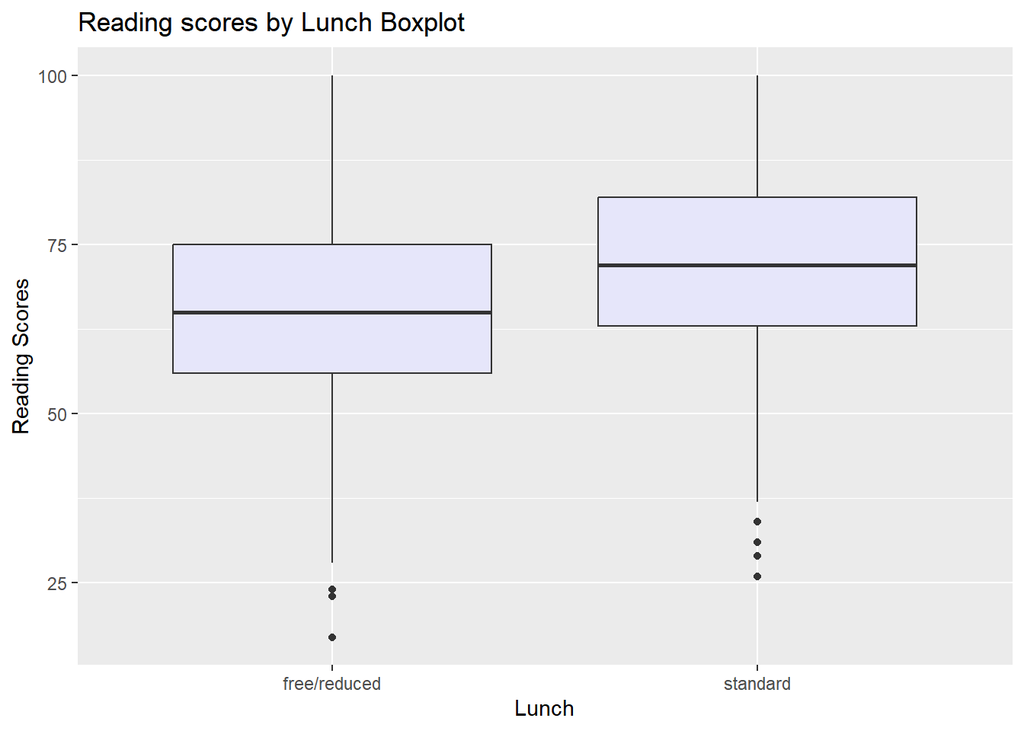

```r
br <- ggplot(students, aes(Lunch, Reading_Score))
br <- br + geom_boxplot(fill='lavender')
br <- br + ggtitle("Reading scores by Lunch Boxplot")
br <- br + xlab("Lunch") + ylab("Reading Scores")
br
```

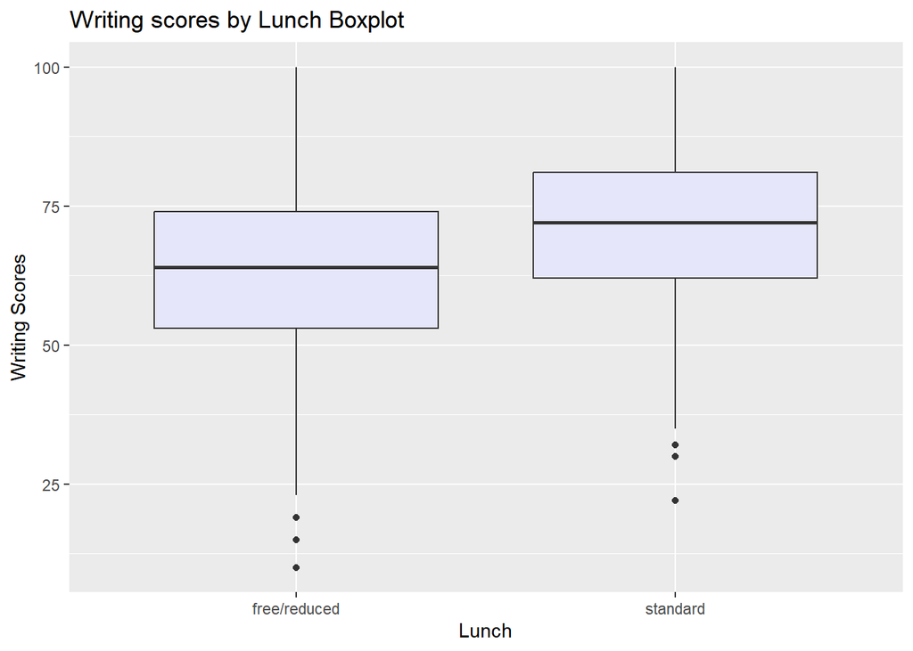

```r
bw <- ggplot(students, aes(Lunch, Writing_Score))
bw <- bw + geom_boxplot(fill='lavender')
bw <- bw + ggtitle("Writing scores by Lunch Boxplot")
bw <- bw + xlab("Lunch") + ylab("Writing Scores")
bw
```

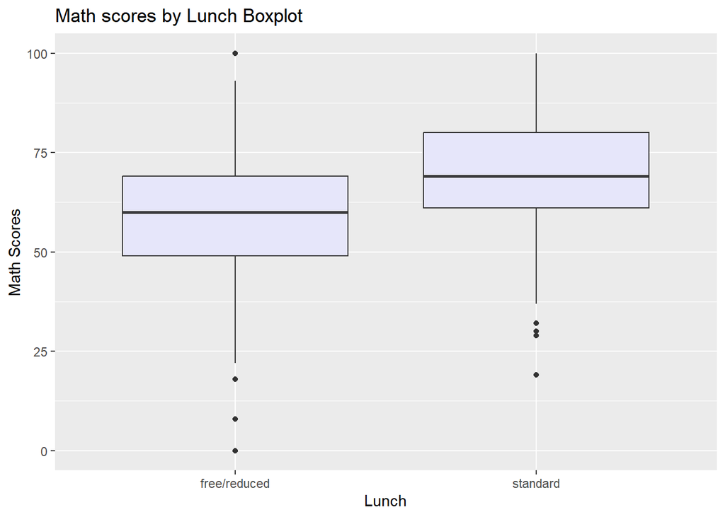

```r
bm <- ggplot(students, aes(Lunch, Math_Score))
bm <- bm + geom_boxplot(fill='lavender')
bm <- bm + ggtitle("Math scores by Lunch Boxplot")
bm <- bm + xlab("Lunch") + ylab("Math Scores")
bm
```

Người ta thấy rằng điểm viết, điểm toán và điểm đọc đều có phân phối cao trong “tiêu chuẩn”(Lunch_standard). Để tìm hiểu xem những khác biệt này có đáng kể hay không, một bài kiểm tra t-test đã được tiến hành trên biến mean.score, là điểm trung bình của từng môn học trong số ba môn học của sinh viên.

Trước khi thử nghiệm t-test , một thử nghiệm phương sai bằng nhau đã được thực hiện. Đặt giả thuyết:

H0: Phương sai của hai nhóm standard và free/reduced là như nhau

H1: Phương sai của hai nhóm standard và free/reduced là khác nhau

```r
students$avg.score =  round(apply(students[,c("Math_Score","Reading_Score","Writing_Score")],FUN = mean, MARGIN = 1),2)
var.test(students$avg.score ~ students$Lunch)
```

```
##
##  F test to compare two variances
##
## data:  students$avg.score by students$Lunch
## F = 1.2022, num df = 354, denom df = 644, p-value = 0.04632
## alternative hypothesis: true ratio of variances is not equal to 1
## 95 percent confidence interval:
##  1.002997 1.448120
## sample estimates:
## ratio of variances
##           1.202193
```

Vì giá trị p của kết quả Kiểm tra F < 0,05 nên giả thuyết H0 bị bác bỏ. Do đó, có thể thấy phương sai của hai nhóm là khác nhau.

Dựa trên những kết quả này, một bài kiểm tra t-test khác được thực hiện.

Đặt giả thuyết: H0: Thu nhập của cha mẹ không liên quan đến điểm số của học sinh

H1: Thu nhập của cha mẹ có liên quan đến điểm số của học sinh

```r
t.test(students$avg.score ~ students$Lunch,var.equal = FALSE)
```

```
##
##  Welch Two Sample t-test
##
## data:  students$avg.score by students$Lunch
## t = -9.3232, df = 674.61, p-value < 2.2e-16
## alternative hypothesis: true difference in means between group free/reduced and group standard is not equal to 0
## 95 percent confidence interval:
##  -10.457339  -6.818922
## sample estimates:
## mean in group free/reduced     mean in group standard
##                   62.19899                   70.83712
```

Vì giá trị p < 2.2e-16 là rất nhỏ nên bác bỏ giả thuyết H0. Do đó, sự khác biệt về kết quả học tập trung bình của học sinh theo thu nhập của phụ huynh có thể được coi là một sự khác biệt đáng kể.

3. Mối quan hệ giữa trình độ học vấn của cha mẹ và điểm kiểm tra

Tập dữ liệu StudentsPerformance có biến parental.level.of.education Biến parental.level.of.education là biến đại diện cho trình độ học vấn của cha mẹ và có các giá trị như bằng cao đẳng, bằng cử nhân, trung học phổ thông, cao học, đại học nào đó và trung học nào đó.

```r
table(dt$parental_level_of_education)
```

```
##
## associate's degree  bachelor's degree        high school    master's degree
##                222                118                196                 59
##       some college   some high school
##                226                179
```

tạo tập dữ liệu students gồm 3 biến parental.level.of.education, Math_Score,Reading_Score, Writing_Score

```r
students <- subset(dt, select = c(-race.ethnicity,-lunch,-gender,-test_preparation_course, -total_score))
colnames(students) <-  c("Parent_Education","Math_Score","Reading_Score","Writing_Score")

students <- students %>%
  pivot_longer(cols = c(Math_Score, Reading_Score, Writing_Score), names_to = "subject", values_to = "score") %>%
  separate(subject, c("subject",NA))

students$Parent_Education <- factor(students$Parent_Education, levels = c("some high school", "high school", "some college", "associate's degree", "bachelor\'s degree", "master\'s degree"))

#phân loại thành tích học tập của phụ huynh
```

```r
edu_score<- students %>%
  group_by(Parent_Education, subject) %>%
  summarise(
    avg.score = round(mean(score),1),
    std.score = round(sd(score),1),
    .groups = "drop"
  )

gp <- ggplot(edu_score,
             aes(x = Parent_Education)) +
  geom_point(aes(y = avg.score), color = "tomato", shape = 18, size = 5) +
  geom_point(aes(y = std.score/0.2), color = "slategray3", shape = 20, size = 5) +
  scale_y_continuous(
    "avg.score",
    sec.axis = sec_axis(~. * 0.2, name = "std.score")
  ) +
  facet_wrap(~subject, nrow = 3) +
  theme(
    axis.text.x = element_text(angle = 10, vjust = 0.6),
    axis.text = element_text(size = 12),
    axis.title.x = element_text(size = 20),
    axis.title.y.left = element_text(size = 20, color = "tomato"),
    axis.title.y.right = element_text(size = 20, color = "slategray3"),
    legend.text = element_text(size = 12),
    legend.title = element_text(size = 15),
    strip.text = element_text(size = 15)
  )
```

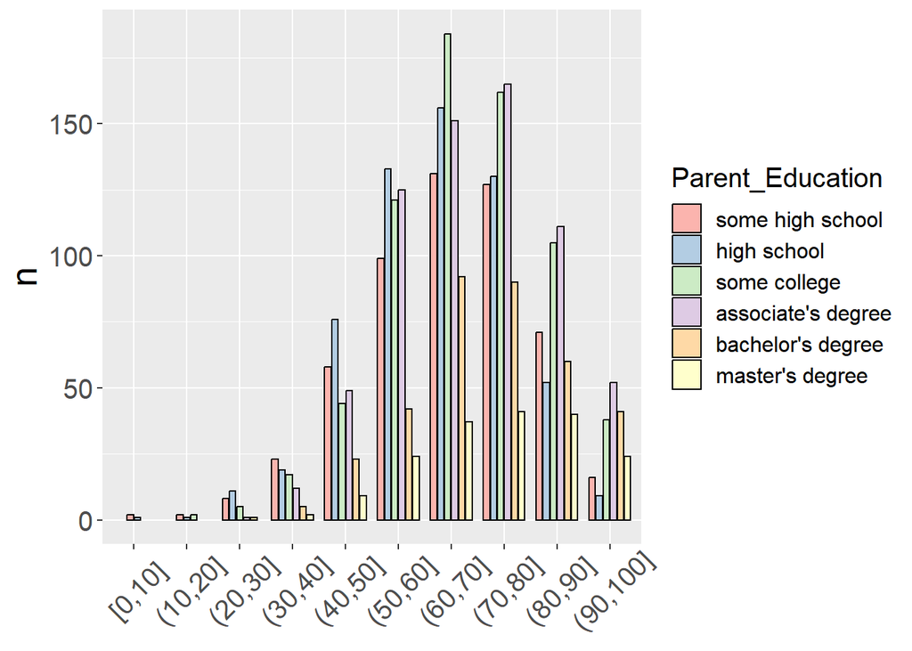

```r
histogram <- students %>%
  mutate(bin = cut_interval(score, n=10)) %>%
  group_by(bin, Parent_Education) %>%
  summarise(
    n = n(),
    .groups = "drop"
  )

hist <- ggplot(histogram,
               aes(
                 x = bin,
                 y = n,
                 fill = Parent_Education
               )) +
  geom_bar(stat = "identity",
           position = position_dodge2(preserve = "single"),
           color = "black",
           width = 0.8) +
  scale_fill_brewer(palette = "Pastel1") +
  theme(
    axis.text.x = element_text(angle = 45, vjust = 0.6),
    axis.title.x = element_blank(),
    axis.text = element_text(size = 15),
    axis.title = element_text(size = 20),
    legend.text = element_text(size = 12),
    legend.title = element_text(size = 15),
    strip.text = element_text(size = 15)
  )
hist
```

Kết luận: Mối quan hệ giữa giới tính và điểm các môn toán, đọc, viết

Thông qua trực quan hóa dữ liệu, chúng tôi đưa ra giả thuyết rằng học sinh nữ có kỹ năng ngôn ngữ (đọc và viết) tốt hơn học sinh nam và học sinh nam có kỹ năng toán học tốt hơn học sinh nữ.

mối quan hệ giữa trình dộ học vấn và thu nhập của cha mẹ đối với điểm các môn toán, đọc, viết

Kiểm định t-test cho thấy có mối quan hệ đáng kể giữa thu nhập của cha mẹ và điểm số của học sinh. Nhóm chúng em cho rằng điều này cũng có thể được coi là thực tế là học sinh từ các gia đình có thu nhập thấp không được tạo cơ hội giáo dục bình đẳng.

Qua phân tích ta thấy rằng điểm số của con cái của cha mẹ có trình độ học vấn cao là tương đối cao và điều này là do kinh nghiệm và sự quan tâm, dạy dỗ truyền đạt của cha mẹ đối với giáo dục lên con cái của họ đã ảnh hưởng đến điểm số của con cái họ.

Qua việc phân tích các yếu tố giới tính, thu nhập và trình độ của cha mẹ có liên quan đến điểm các môn của học sinh thì nhóm chúng em đã có được giải pháp rằng: +về giới: việc các học sinh Nam chiếm ưu thế về điểm môn Toán hơn các học sinh nữ và ngược lại thì ta có thể khai khác các điểm mạnh , tiềm năng về lĩnh của các em học sinh và đưa ra giải pháp giáo dục phù hợp và hiệu quả + về thu nhập của học sinh: ta thấy rằng qua phân tích và trong thực tế ở giai đoạn hiện nay việc thu nhập của một hộ gia đình ở mức trun bình hoặc thấp sẽ ảnh hưởng đến kết quả học tập của các em học sinh, chính vì vậy chúng ta cần giải quyết vấn đề kinh tế, học phí và bữa ăn học đường của các học sinh sinh viên, các quỹ học bổng và bảo trợ học sinh sinh viên để đảm bảo được sự bình đẳng trong giáo dục. +về trình độ học vấn của phụ huynh: quá rõ ràng sau khi phân tích ta thấy rằng việc phụ huynh học sinh có trình độ dân trí cao hơn thì con của họ cũng có tỉ lệ đạt thành tích học tập tốt hơn, họ quan tâm và truyền đạt kiến thức kinh nghiệm và văn hoá để giáo dục con em của họ tốt hơn. Cho nên đối với những bậc phụ huynh tuy có những trình độ khác nhau nhưng việc cải thiện dân trí và sự quan tâm cho các con em của họ là điều hoàn toàn có thể, để góp phần nâng cao học thức và dân trí, gia đình có dân trí cao thúc đẩy các con em có ý thức trong việc học tập hơn và góp phần nâng cao dân trí trong xã hội.

Quan kết quả phân tích trên, nhóm chúng em đã tìm được những biến gây tác động đến điểm số của học sinh. Để tiếp tục phân tích sâu hơn tằng trong các biến của tập dữ liệu, nhóm chúng em sử dụng thêm mô hình RANDOM FOREST để tìm xem đâu là biến quan trọng nhất gây tác động đến điểm số của học sinh.

```r
Students <- dt %>% rename(race = race.ethnicity, parent.ed = parental_level_of_education,
                                test.prep = test_preparation_course, m.score = math_score,
                                r.score = reading_score, w.score = writing_score)
colnames(Students)
```

```
## [1] "gender"      "race"        "parent.ed"   "lunch"       "test.prep"
## [6] "m.score"     "r.score"     "w.score"     "total_score"
```

Bộ dữ liệu Students sử dụng cho mô hình RF

```r
#kiểm tra xem có giá trị nào bị thiếu hoặc NA
sapply(Students, function(x)sum(is.na(x)))
```

```
##      gender        race   parent.ed       lunch   test.prep     m.score
##           0           0           0           0           0           0
##     r.score     w.score total_score
##           0           0           0
```

thêm Điểm trung bình làm biến mới trong dữ liệu, vì nó sẽ phù hợp hơn để kiểm tra hiệu suất của học sinh.

```r
Students <- Students %>% mutate (Avg.score = (r.score + m.score + w.score)/3)
head(Students,n=10)
```

```
##    gender    race          parent.ed        lunch test.prep m.score r.score
## 1  female group B  bachelor's degree     standard      none      72      72
## 2  female group C       some college     standard completed      69      90
## 3  female group B    master's degree     standard      none      90      95
## 4    male group A associate's degree free/reduced      none      47      57
## 5    male group C       some college     standard      none      76      78
## 6  female group B associate's degree     standard      none      71      83
## 7  female group B       some college     standard completed      88      95
## 8    male group B       some college free/reduced      none      40      43
## 9    male group D        high school free/reduced completed      64      64
## 10 female group B        high school free/reduced      none      38      60
##    w.score total_score Avg.score
## 1       74    72.66667  72.66667
## 2       88    82.33333  82.33333
## 3       93    92.66667  92.66667
## 4       44    49.33333  49.33333
## 5       75    76.33333  76.33333
## 6       78    77.33333  77.33333
## 7       92    91.66667  91.66667
## 8       39    40.66667  40.66667
## 9       67    65.00000  65.00000
## 10      50    49.33333  49.33333
```

MÔ HÌNH RỪNG NGẪU NHIÊN Rừng ngẫu nhiên là một thuật toán phân loại bao gồm nhiều cây quyết định. Nó sử dụng tính năng đóng gói và tính năng ngẫu nhiên khi xây dựng từng cây riêng lẻ để cố gắng tạo ra một rừng cây không tương quan mà dự đoán của ủy ban chính xác hơn dự đoán của bất kỳ cây riêng lẻ nào.

bộ TRAIN/TEST

```r
#Sử dụng nrow để lấy số hàng trong bộ dữ liệu Students (N)
(N <- nrow(Students))
```

```
## [1] 1000
```

```r
# tính xem 75% của N phải là bao nhiêu hàng, sử dụng hàm round() để lấy số nguyên
(target <- round(N*.75))
```

```
## [1] 750
```

```r
# tạo một vectơ gồm N biến ngẫu nhiên thống nhất
st <- runif(N)
#Sử dụng st để tạo tập huấn luyện: student_train(75% dữ liệu) và student_test(25% dữ liệu)
Student_train <- Students[st < .75, ]
Student_test <- Students[st >= .75, ]

nrow(Student_train)
```

```
## [1] 780
```

```r
nrow(Student_test)
```

```
## [1] 220
```

```r
#seed
set.seed(122)
```

XÂY DỰNG MÔ HÌNH RANDOM FOREST TRÊN BỘ DỮ LIỆU Student_train

```r
# Kiểm tra str của Student_train
str(Student_train)
```

```
## 'data.frame':    780 obs. of  10 variables:
##  $ gender     : chr  "female" "male" "male" "female" ...
##  $ race       : chr  "group B" "group A" "group C" "group B" ...
##  $ parent.ed  : chr  "master's degree" "associate's degree" "some college" "associate's degree" ...
##  $ lunch      : chr  "standard" "free/reduced" "standard" "standard" ...
##  $ test.prep  : chr  "none" "none" "none" "none" ...
##  $ m.score    : int  90 47 76 71 40 38 58 40 65 78 ...
##  $ r.score    : int  95 57 78 83 43 60 54 52 81 72 ...
##  $ w.score    : int  93 44 75 78 39 50 52 43 73 70 ...
##  $ total_score: num  92.7 49.3 76.3 77.3 40.7 ...
##  $ Avg.score  : num  92.7 49.3 76.3 77.3 40.7 ...
```

```r
# Hạt giống ngẫu nhiên để tái tạo kết quả
seed <- set.seed(1234)
# outcome column
(outcome <- "Avg.score")
```

```
## [1] "Avg.score"
```

```r
# Biến truyền vào
(vars <- c("gender", "race", "parent.ed", "lunch", "test.prep"))
```

```
## [1] "gender"    "race"      "parent.ed" "lunch"     "test.prep"
```

```r
# Tạo chuỗi công thức cho Điểm trung bình dưới dạng một hàm của đầu vào
(fmla <- paste(outcome, "~", paste(vars, collapse = " + ")))
```

```
## [1] "Avg.score ~ gender + race + parent.ed + lunch + test.prep"
```

```r
# Gọi thư viện ranger
# nếu kết quả là số, ranger sẽ tự động thực hiện hồi quy thay vì phân loại.
# Lắp và in mô hình Random Forest
(model_rf <- ranger(fmla, Student_train, num.trees = 200, respect.unordered.factors = "order", seed = seed))
```

```
## Ranger result
##
## Call:
##  ranger(fmla, Student_train, num.trees = 200, respect.unordered.factors = "order",      seed = seed)
##
## Type:                             Regression
## Number of trees:                  200
## Sample size:                      780
## Number of independent variables:  5
## Mtry:                             2
## Target node size:                 5
## Variable importance mode:         none
## Splitrule:                        variance
## OOB prediction error (MSE):       171.2059
## R squared (OOB):                  0.1727609
```

```r
#respect.unordered.factors giúp ranger mã hóa một cách an toàn và có ý nghĩa các biến phân loại dưới dạng số. Mã hóa này chạy nhanh hơn chuyển đổi biến phân loại thành biến chỉ báo..
```

Dự đoán bằng mô hình RANDOM FOREST

```r
#Dự đoán trên Student_test
Student_test$pred <- predict(model_rf, Student_test)$prediction
#Tính toán RMSE của các dự đoán
Student_test %>%
  mutate(Residual = pred - Avg.score) %>% #Calculating the residual
  summarise(rmse = sqrt(mean(Residual^2)))  #calculating RMSE
```

```
##       rmse
## 1 12.20226
```

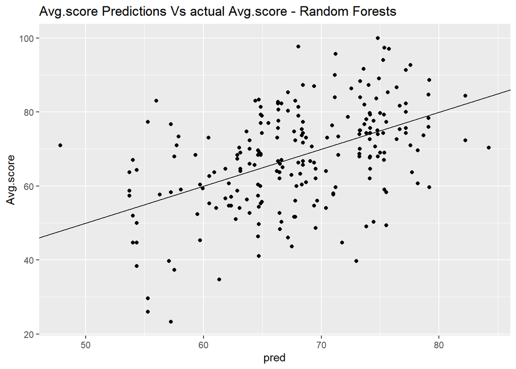

```r
ggplot(Student_test, aes(pred, Avg.score)) + geom_point() + geom_abline() +
  labs(title = "Avg.score Predictions Vs actual Avg.score - Random Forests")
```

```r
# thể hiện biểu đồ: điểm trung bình dự đoán so với thực tế
```

VARIABLE IMPORTANCE

```r
student_T <- Student_train %>% select(-m.score, -r.score, -w.score,-total_score) # tạo bộ dữ liệu TRain student_T loại các biến điểm toán đọc viết
glimpse(student_T) # xem mọi cột trong khung dữ liệu.
```

```
## Rows: 780
## Columns: 6
## $ gender    <chr> "female", "male", "male", "female", "male", "female", "male"…
## $ race      <chr> "group B", "group A", "group C", "group B", "group B", "grou…
## $ parent.ed <chr> "master's degree", "associate's degree", "some college", "as…
## $ lunch     <chr> "standard", "free/reduced", "standard", "standard", "free/re…
## $ test.prep <chr> "none", "none", "none", "none", "none", "none", "none", "non…
## $ Avg.score <dbl> 92.66667, 49.33333, 76.33333, 77.33333, 40.66667, 49.33333, …
```

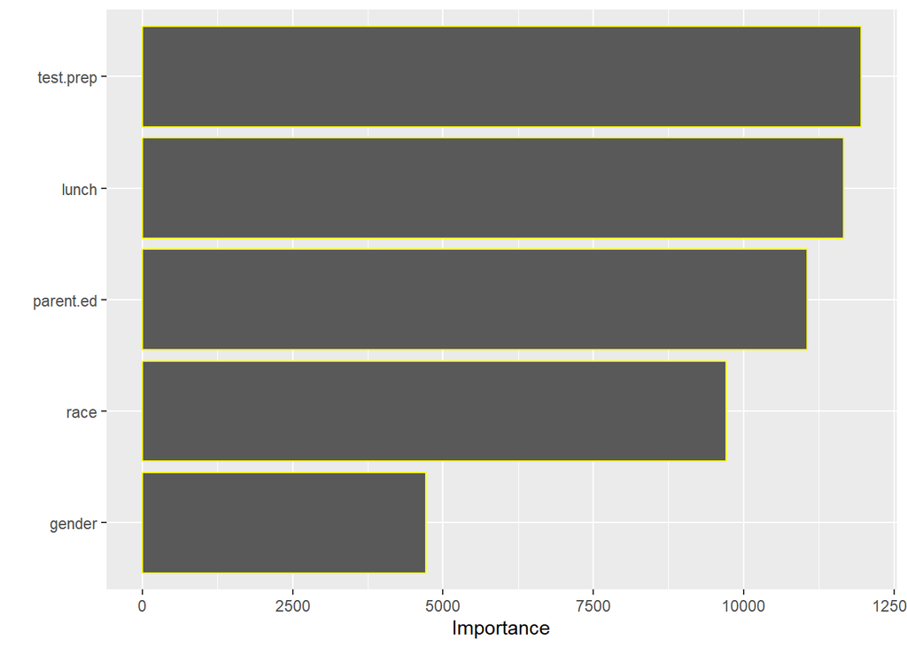

```r
rand_forest(mode = "regression") %>%
  set_engine("ranger", importance="impurity") %>%
  fit(Avg.score~., data=student_T)%>%
  vip:: vip(aesthetic=list(color="yellow"))
```

```r
MakeNum <- function(x) as.numeric(as.factor(x))

dtn <- mutate(dt, across(1:5, MakeNum))
dtn
```

[output not shown]

[output cut: 1987 more lines]

```r
str(dtn)
```

```
## 'data.frame':    1000 obs. of  9 variables:
##  $ gender                     : num  1 1 1 2 2 1 1 2 2 1 ...
##  $ race.ethnicity             : num  2 3 2 1 3 2 2 2 4 2 ...
##  $ parental_level_of_education: num  2 5 4 1 5 1 5 5 3 3 ...
##  $ lunch                      : num  2 2 2 1 2 2 2 1 1 1 ...
##  $ test_preparation_course    : num  2 1 2 2 2 2 1 2 1 2 ...
##  $ math_score                 : int  72 69 90 47 76 71 88 40 64 38 ...
##  $ reading_score              : int  72 90 95 57 78 83 95 43 64 60 ...
##  $ writing_score              : int  74 88 93 44 75 78 92 39 67 50 ...
##  $ total_score                : num  72.7 82.3 92.7 49.3 76.3 ...
```

```r
glimpse(dtn)
```

```
## Rows: 1,000
## Columns: 9
## $ gender                      <dbl> 1, 1, 1, 2, 2, 1, 1, 2, 2, 1, 2, 2, 1, 2, …
## $ race.ethnicity              <dbl> 2, 3, 2, 1, 3, 2, 2, 2, 4, 2, 3, 4, 2, 1, …
## $ parental_level_of_education <dbl> 2, 5, 4, 1, 5, 1, 5, 5, 3, 3, 1, 1, 3, 5, …
## $ lunch                       <dbl> 2, 2, 2, 1, 2, 2, 2, 1, 1, 1, 2, 2, 2, 2, …
## $ test_preparation_course     <dbl> 2, 1, 2, 2, 2, 2, 1, 2, 1, 2, 2, 2, 2, 1, …
## $ math_score                  <int> 72, 69, 90, 47, 76, 71, 88, 40, 64, 38, 58…
## $ reading_score               <int> 72, 90, 95, 57, 78, 83, 95, 43, 64, 60, 54…
## $ writing_score               <int> 74, 88, 93, 44, 75, 78, 92, 39, 67, 50, 52…
## $ total_score                 <dbl> 72.66667, 82.33333, 92.66667, 49.33333, 76…
```

Tiếp đó, tạo tập dữ liệu dùng để train và test model với train chứa 70% và test chứa 30% của dữ liệu.

```r
set.seed(123)
samplesize <- round(0.7 * nrow(dtn), 0)
index <- sample(seq_len(nrow(dtn)), size = samplesize)

data_train <- dtn[index, ]
data_test <- dtn[-index, ]
```

Sau đó xây dựng một model Multipe Linear Regression

```r
#xay dung model Multiple Linear Regression
student_lm <- lm(total_score ~ reading_score + writing_score + gender + test_preparation_course, data = data_train)

summary(student_lm)
```

```
##
## Call:
## lm(formula = total_score ~ reading_score + writing_score + gender +
##     test_preparation_course, data = data_train)
##
## Residuals:
##    Min     1Q Median     3Q    Max
## -6.153 -1.235 -0.089  1.361  5.446
##
## Coefficients:
##                         Estimate Std. Error t value Pr(>|t|)
## (Intercept)             -9.63212    0.63944 -15.063  < 2e-16 ***
## reading_score            0.42244    0.01766  23.915  < 2e-16 ***
## writing_score            0.57857    0.01755  32.974  < 2e-16 ***
## gender                   4.56225    0.15720  29.021  < 2e-16 ***
## test_preparation_course  1.23915    0.16392   7.559 1.28e-13 ***
## ---
## Signif. codes:  0 '***' 0.001 '**' 0.01 '*' 0.05 '.' 0.1 ' ' 1
##
## Residual standard error: 1.932 on 695 degrees of freedom
## Multiple R-squared:  0.9809, Adjusted R-squared:  0.9808
## F-statistic:  8929 on 4 and 695 DF,  p-value: < 2.2e-16
```

```r
#du doan tap du lieu data_test
lm_pred <- predict(student_lm, newdata = data_test %>% select(-total_score))

# RMSE of train dataset
RMSE(pred = student_lm$fitted.values, obs = data_train$total_score)
```

```
## [1] 1.925081
```

#Root Mean Square Error (RMSE) hoặc Root Mean Square Deviation (RMSD) là căn bậc hai của mức trung bình của các sai số bình phương. RMSE là độ lệch chuẩn của các phần dư (sai số dự đoán) #Root Mean Square Error (RMSE) RMSE cho biết mức độ phân tán các giá trị dự đoán từ các giá trị thực tế. #RMSE càng thấp, mô hình và dự đoán của nó càng tốt

```r
# RMSE of test dataset
RMSE(pred = lm_pred, obs = data_test$total_score)
```

```
## [1] 1.99949
```

# Quan sát kết quả ta thấy kết quả RMSE của tập dữ liệu train và test đều thấp . Điều này cho thấy model dự đoán tốt.

#Tiếp theo sẽ kiểm tra mô hình có tuyến tính không. Để kiểm tra thì ta xem xét phần dư nếu

- có phương sai không đổi
- Phần dư có trị trung bình bằng 0
- Không có tương quan giữa các phần dư

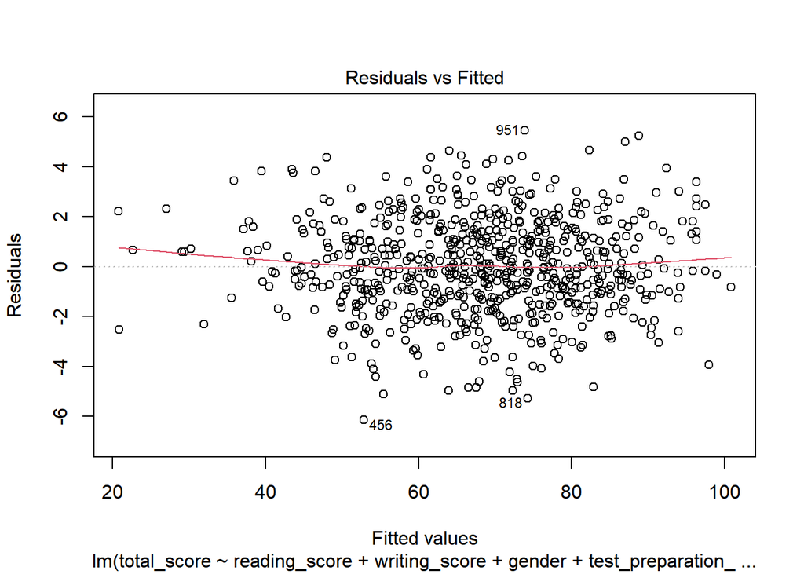

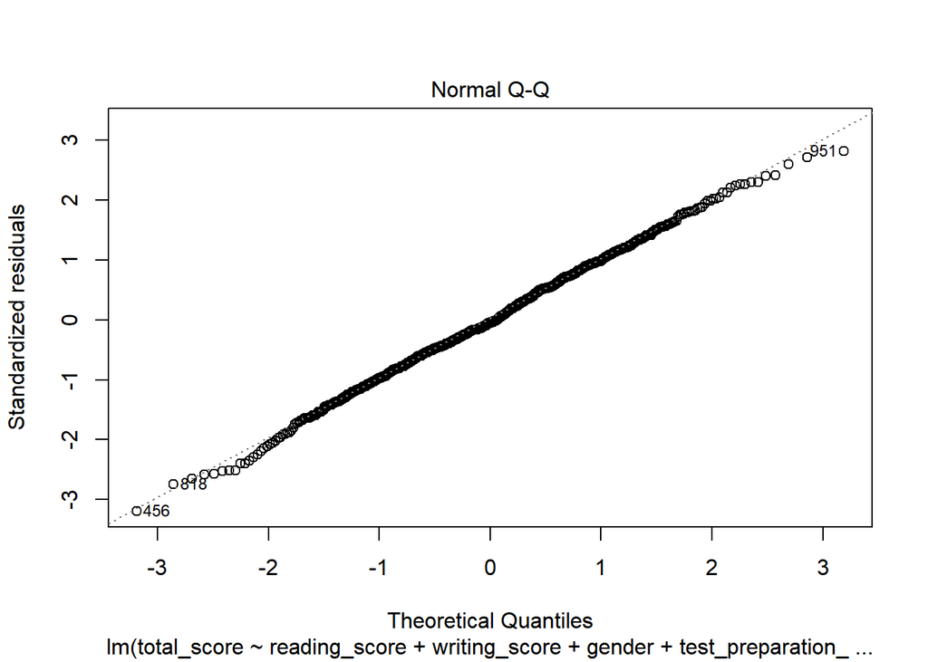

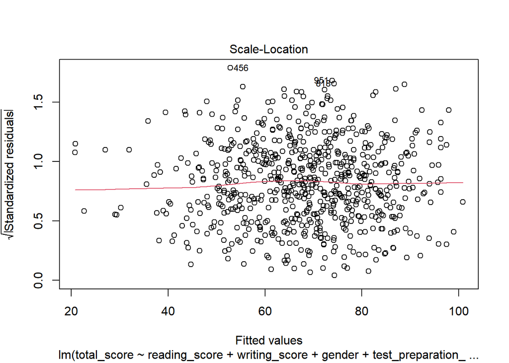

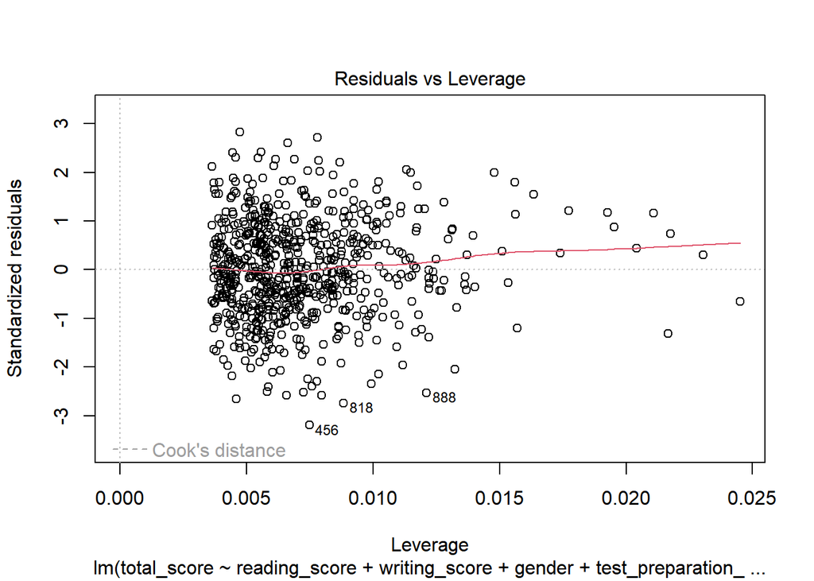

```r
plot(student_lm)
```